# DASM Practical 7

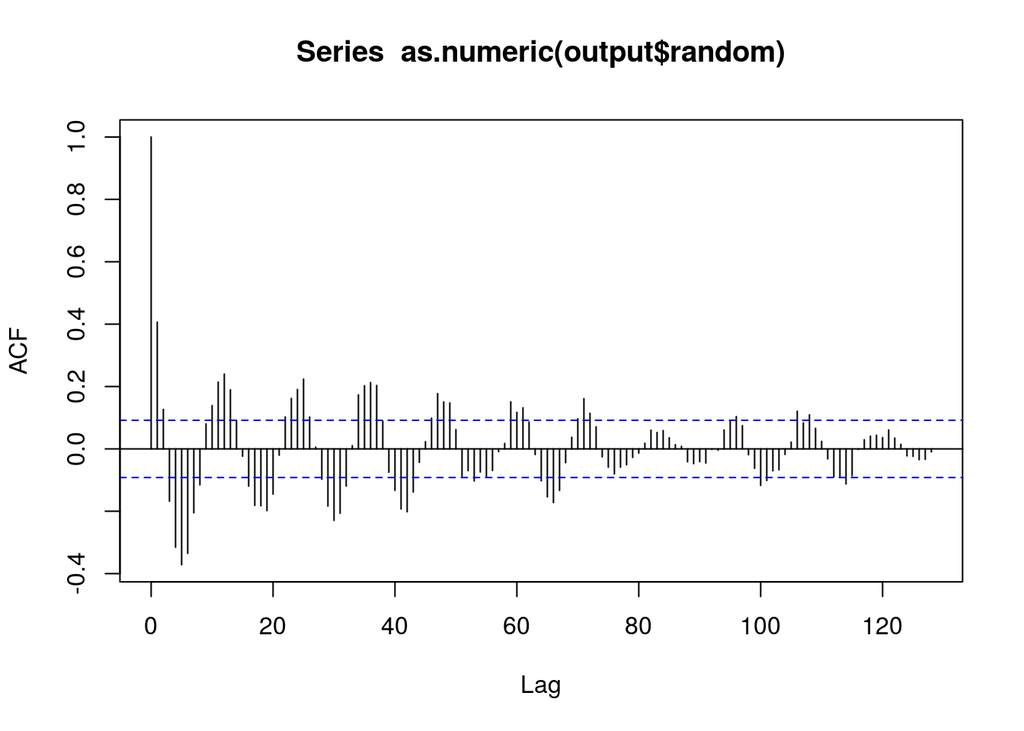

```r
## Find the ACF of the random component of the time series data
acf_des <- acf(as.numeric(output$random), type = "correlation", lag.max = 128, na.action=na.omit)
```

Note that if you don’t use `as.numeric` as shown above, the values on the x axis will be based on the cycle number, which for this data set represents the year. In the plot above, the numbers correspond to the months.

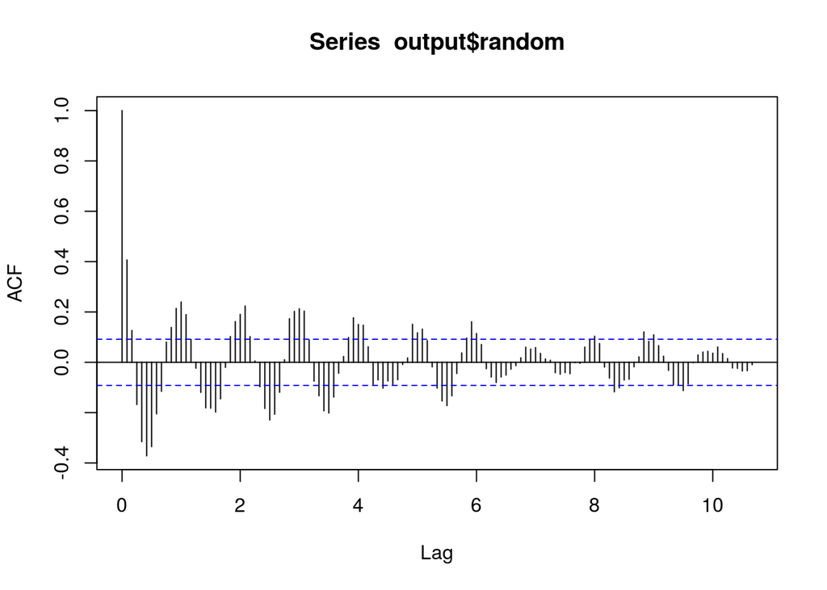

```r
acf_des <- acf(output$random, type = "correlation", lag.max = 128, na.action=na.omit)
```

What we see above is that there is still some seasonality in the calculated random noise component, but not very much.

What would happen if we analyzed a time series composed of completely random values?

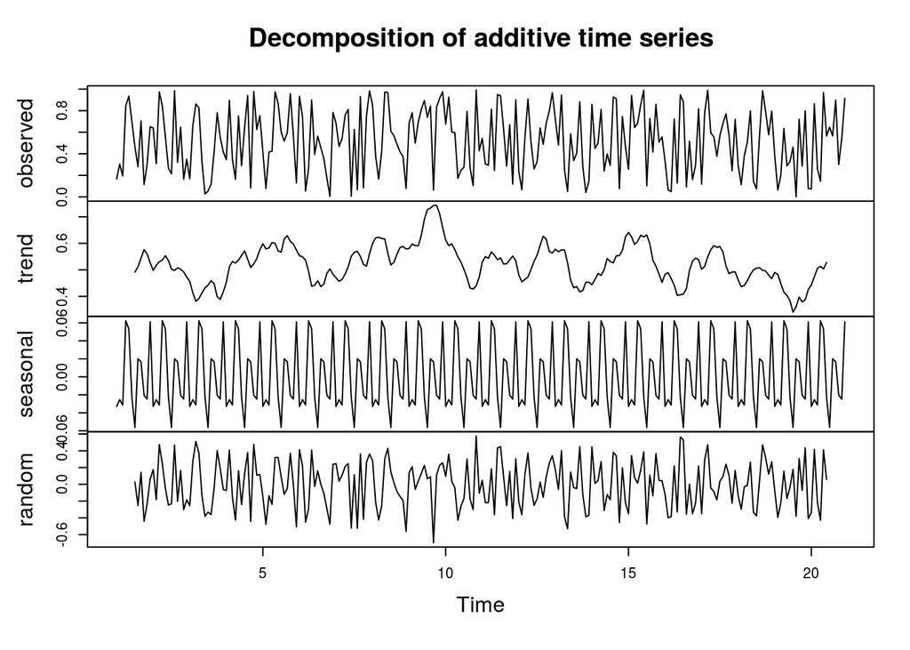

```r
## 20 "years" of random values uniformly distributed
t_ser_random <- ts(runif(20*12), freq = 12)
output = decompose(t_ser_random)
plot(output)
```

The `decompose` method does show a seasonal component, but it’s important to note the scale - the range of random values is much greater than the range of seasonal values

#### Exercise

Decompose the time series from `Practical7_time_series.txt` using classical decomposition.

Hint: you need to construct an appropriate time series object first using `ts()`. From the discussion about this data set above, you should be able to pick the correct frequency for the time series object.

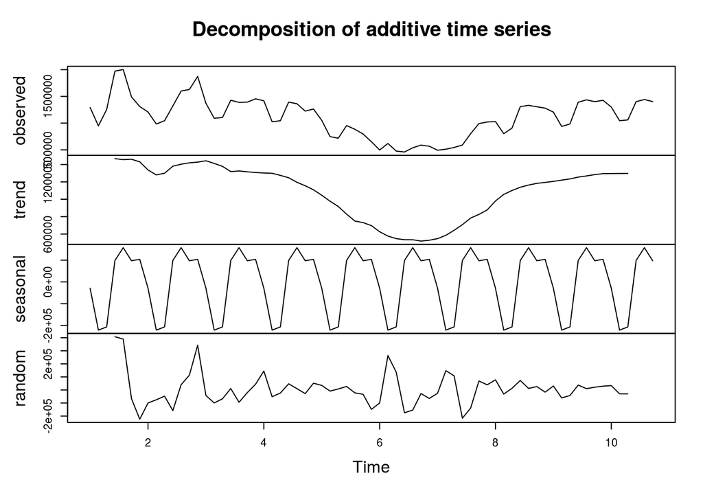

## Seasonal Decomposition of Time Series by Loess (stl)

### Reminder

The basic syntax for the `stl` function is:

```r
stl(x, s.window,
    t.window = NULL,
    l.window,
    robust = FALSE)
```

Arguments:

- `x` - univariate time series to be decomposed. This should be an object of class “ts” with a frequency greater than one.
- `s.window` - either the character string “periodic” or the span (in lags) of the loess window for seasonal extraction, which should be odd and at least 7, according to Cleveland et al. This has no default.
- `t.window` - the span (in lags) of the loess window for trend extraction, which should be odd. If NULL, the default, nextodd(ceiling((1.5*period) / (1-(1.5/s.window)))), is taken.
- `l.window` - the span (in lags) of the loess window of the low-pass filter used for each subseries. Defaults to the smallest odd integer greater than or equal to frequency(x) which is recommended since it prevents competition between the trend and seasonal components. If not an odd integer its given value is increased to the next odd one.
- `robust` - logical indicating if robust fitting be used in the loess procedure.

### Overview

In the `sts` function there is an inner loop that separates the seasonal and trend component. This works in principle similar to classical decomposition, except that it uses more sophisticated smoothing methods.

Therefore you can set a smoothing window (`l.window`) for the seasonal component. This is by default equal to the next odd integer which is greater than or equal to the cycle length. For the purposes of this practical, it is better to leave it like this.

You can set a window (`s.window`) over how many cycles the seasonal cycle can vary. In the classical decomposition all the seasonal cycles are simply averaged. This is done here by a more complicated weighted-average/fitting method. This number should be odd and >=7.

You can play around with these parameters, to get the trend estimate you like.

There is an optional outer loop, that provides robustness. This is recommended if you have many outliers or not-well behaved time series. You set this to `TRUE` or `FALSE` using the `robust` parameter in the `stl` function.

### Example

We again use the `co2_vals` data.

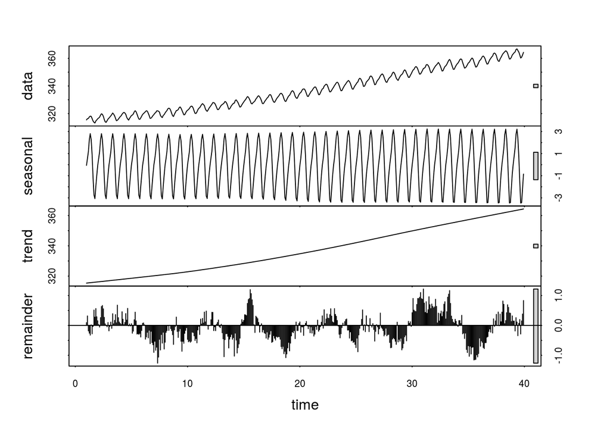

```r
t_ser1 <- ts(co2_vals$co2_ppm, freq = 12)
output1 = stl(t_ser1, s.window = 15, t.window = 12*15+1)
plot(output1)
```

To extract the different parts of the decomposed time series, we will need to use a different syntax than we did with the `decompose` function. First we look at the first few rows of the `time.series` matrix associated with `output1`:

```r
head(output1$time.series)
```

```
##          seasonal    trend   remainder
## Jan 1 -0.05661336 315.3838  0.09277872
## Feb 1  0.54409254 315.4493  0.31657048
## Mar 1  1.16996948 315.5148 -0.18480881
## Apr 1  2.23930954 315.5803 -0.25965122
## May 1  2.80894579 315.6458 -0.32478982
## Jun 1  2.27172798 315.7113  0.01692564
```

In order to access these, we need to use the following syntax:

- `output1$time.series[,"seasonal"]`
- `output1$time.series[,"trend"]`
- `output1$time.series[,"remainder"]`

We now take the remainder and see the auto-correlation:

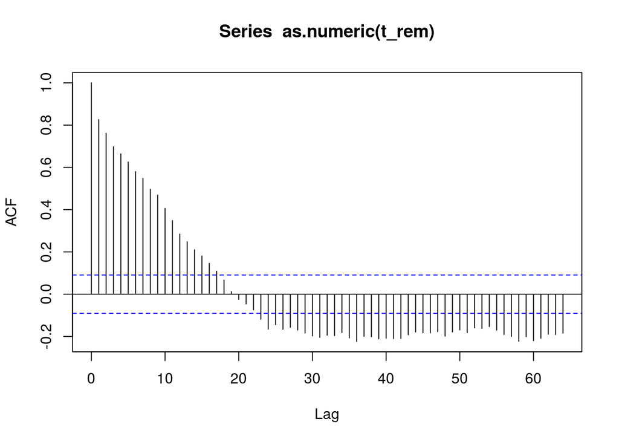

```r
t_rem <- output1$time.series[,"remainder"]
acf_rem <-acf(as.numeric(t_rem), type = "correlation", lag.max = 64)
```

### Exercise

Decompose the time series from `Practical7_time_series.txt` using `stl` decomposition. Again use `ts` and and an appropriate value for `frequency` as you did in the previous exercise above.

Play with the parameters `s.window` and `t.window` and observe how this influence the trend, the remainder, and the seasonal pattern.

Note that the results you get may vary a bit from what you see below based on the values you choose for `s.window` and `t.window`.

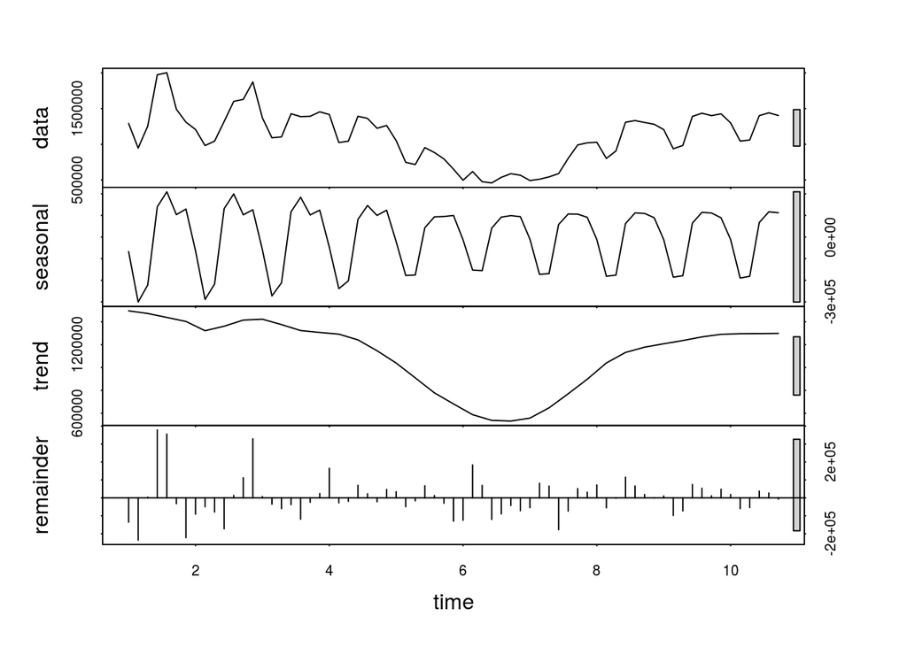

Calculate and plot the de-trended time series.

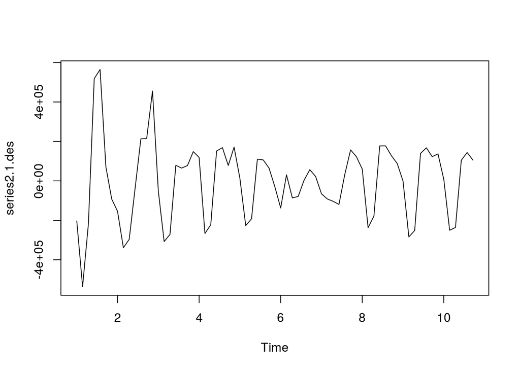

Plot and interpret the ACF of the de-trended time series:

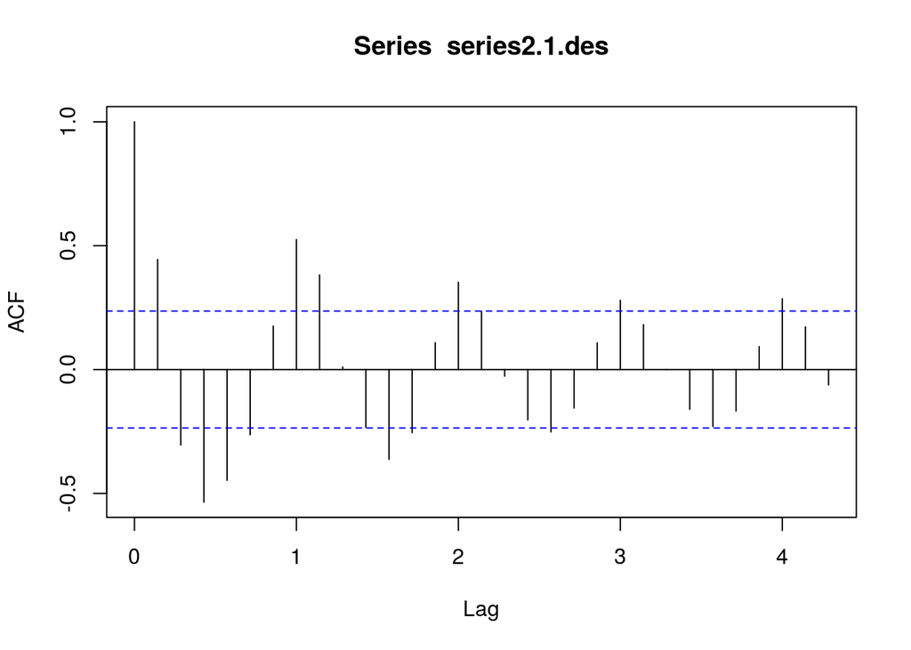

With the help of the ACF investigate if the remainder still contains information, or if it is random noise.

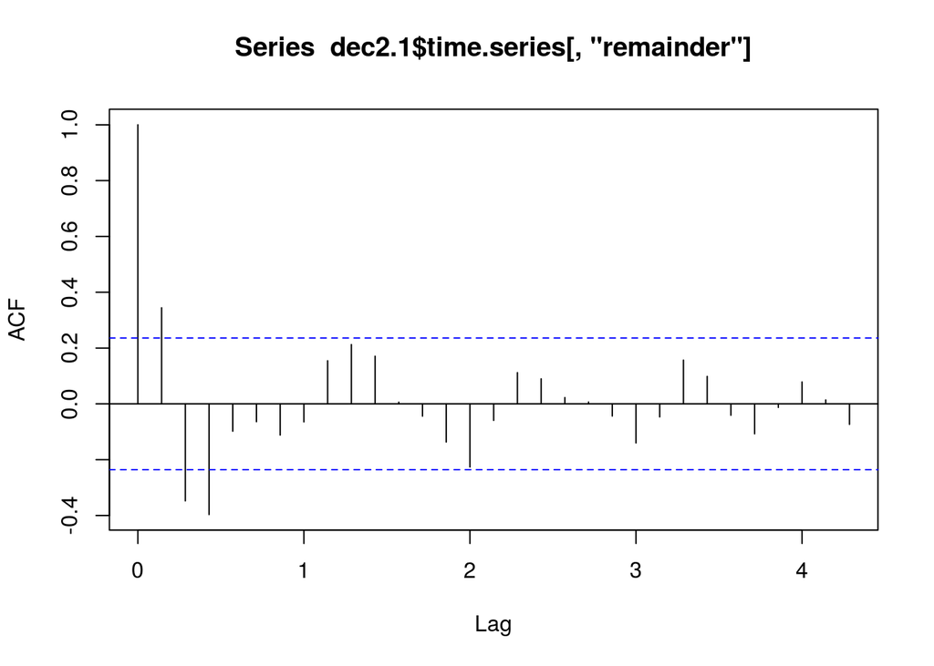

There is an indication of a weak correlation at lag 1 and a weak anticorrelation at lag 2 and 3. This might indicate a causal relationship i.e., that a day with much internet traffic is followed by another day with much internet traffic. But since the correlation is quite weak is might also be due to imperfect decomposition or due to outliers (i.e. the first week with much higher than average weekly cycle.